# R Notebook

## Part 1

This is a preliminary test of the R packages `digest` and `sdcMicro`, which will undertake a variety of data masking functions.

`digest` references:

- [package documentation](https://www.rdocumentation.org/packages/digest/versions/0.6.12/topics/digest)
- Jan Gorecki, [“Data anonymization in R”](https://jangorecki.github.io/blog/2014-11-07/Data-Anonymization-in-R.html)

For this test, we’ll use baseball data housed in the `Lahman` package.

#### packages

```r
library(sdcMicro)
```

#### build working data table

This uses the “Batting” table in the Lahman database. The data are filtered to include only the years 2001 through 2015 inclusive, and then only those batters with a minimum of 100 hits in a season*.

(*Since I can’t be bothered to add the cases where a player was active for two or more teams in season, this is technically “100 hits for any one team in a single season.”)

```r
head(Batting)
```

|  | playerID | yearID | stint | teamID | lgID | G | AB | R | H | X2B | X3B | HR | RBI | SB | CS | BB | SO | IBB | HBP | SH | SF | GIDP |
| --- | --- | --- | --- | --- | --- | --- | --- | --- | --- | --- | --- | --- | --- | --- | --- | --- | --- | --- | --- | --- | --- | --- |
| 1 | abercda01 | 1871 | 1 | TRO | NA | 1 | 4 | 0 | 0 | 0 | 0 | 0 | 0 | 0 | 0 | 0 | 0 | NA | NA | NA | NA | NA |
| 2 | addybo01 | 1871 | 1 | RC1 | NA | 25 | 118 | 30 | 32 | 6 | 0 | 0 | 13 | 8 | 1 | 4 | 0 | NA | NA | NA | NA | NA |
| 3 | allisar01 | 1871 | 1 | CL1 | NA | 29 | 137 | 28 | 40 | 4 | 5 | 0 | 19 | 3 | 1 | 2 | 5 | NA | NA | NA | NA | NA |
| 4 | allisdo01 | 1871 | 1 | WS3 | NA | 27 | 133 | 28 | 44 | 10 | 2 | 2 | 27 | 1 | 1 | 0 | 2 | NA | NA | NA | NA | NA |
| 5 | ansonca01 | 1871 | 1 | RC1 | NA | 25 | 120 | 29 | 39 | 11 | 3 | 0 | 16 | 6 | 2 | 2 | 1 | NA | NA | NA | NA | NA |
| 6 | armstbo01 | 1871 | 1 | FW1 | NA | 12 | 49 | 9 | 11 | 2 | 1 | 0 | 5 | 0 | 1 | 0 | 1 | NA | NA | NA | NA | NA |

```r
year_range <- (2001:2015)
Batting2015 <- Batting %>%
  filter(yearID %in% year_range & H >= 100)
# calculate batting average
Batting2015 <- Batting2015 %>%
  mutate(bat_avg = H / AB) %>%
  select(playerID, yearID, teamID, H, bat_avg) %>%
  arrange(desc(H))
# take a quick look at the resulting table
kable(head(Batting2015))
```

| playerID | yearID | teamID | H | bat_avg |
| --- | --- | --- | --- | --- |
| suzukic01 | 2004 | SEA | 262 | 0.3721591 |
| suzukic01 | 2001 | SEA | 242 | 0.3497110 |
| suzukic01 | 2007 | SEA | 238 | 0.3510324 |
| suzukic01 | 2009 | SEA | 225 | 0.3521127 |
| altuvjo01 | 2014 | HOU | 225 | 0.3409091 |
| suzukic01 | 2006 | SEA | 224 | 0.3223022 |

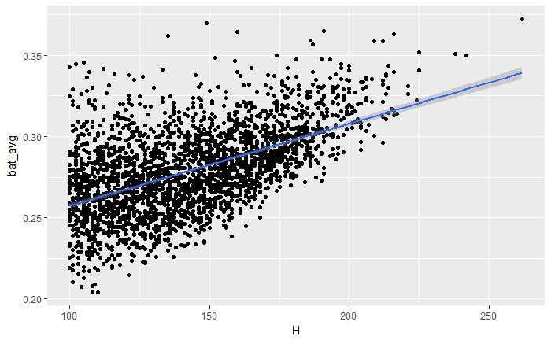

```r
# take a quick look at the distribution
ggplot(Batting2015, aes(x=H, y=bat_avg) ) +
  geom_point() +
  geom_smooth(method = lm)     # add regression line
```

Now we’ve got a data set of 2778 records from 2001 to 2015 inclusive, let’s test the functionality of `digest`.

Note that this draws heavily on the blog post by Jan Gorecki, “[Data anonymization in R]”(https://jangorecki.github.io/blog/2014-11-07/Data-Anonymization-in-R.html).

### Anonymize function

from Gorecki

```r
anonymize <- function(x, algo="crc32"){
  unq_hashes <- vapply(unique(x),
                       function(object) digest(object, algo="crc32"),
                       FUN.VALUE="", USE.NAMES=TRUE)
  unname(unq_hashes[x])
}
```

run using the “SURV” example that Gorecki provides

[output not shown]

```r
# first, a version of the data table with new values appended
SURV_new <- SURV %>%
  mutate(newPost = anonymize(Postal.Code)) %>%
  mutate(newAddress = anonymize(Address))
kable(head(SURV_new))

# or, we can overwrite the existing variables with masked
SURV_mask <- SURV %>%
  mutate(Postal.Code = anonymize(Postal.Code),
         Address = anonymize(Address))
```

One of the clever things about Goreki’s code is that the same masked value is generated for each iteration of a value in the original column. In SURV$Postal.Code, “SW1P 3BU” appears twice, and in the generated masked variable it appears as “265a1b6b”. This means that summaries on Postal.Code will be consistent for that code.

Let’s run it on Battter2015’s playerID column.

[output not shown]

```r
Batting2015_mask2 <- Batting2015 %>%
  mutate(teamID_new = anonymize(teamID))
# pretty print
kable(head(Batting2015_mask))

kable(head(Batting2015_mask2))
```

| playerID | yearID | teamID | H | bat_avg | teamID_new |
| --- | --- | --- | --- | --- | --- |
| suzukic01 | 2004 | SEA | 262 | 0.3721591 | NA |
| suzukic01 | 2001 | SEA | 242 | 0.3497110 | NA |
| suzukic01 | 2007 | SEA | 238 | 0.3510324 | NA |
| suzukic01 | 2009 | SEA | 225 | 0.3521127 | NA |
| altuvjo01 | 2014 | HOU | 225 | 0.3409091 | NA |
| suzukic01 | 2006 | SEA | 224 | 0.3223022 | NA |

Well that’s funny – not all the teamID values are changed; some are ending up as NA.

| teamID_new | teamID |
| --- | --- |
| fbe1a98c | ANA |
| 629c4ebd | ARI |
| a9e1f214 | ATL |
| 3481f6d4 | BAL |
| bd353deb | BOS |
| c36cddd2 | CHA |
| NA | CHN |
| NA | CIN |
| NA | CLE |
| NA | COL |

[output cut: 23 more lines]

Funnier still–it’s an alphabetical issue.

I see that teamID is a factor; could that be the problem?

| playerID | yearID | teamID | H | bat_avg | teamID_chr | teamID_new |
| --- | --- | --- | --- | --- | --- | --- |
| suzukic01 | 2004 | SEA | 262 | 0.3721591 | SEA | 41b4f58e |
| suzukic01 | 2001 | SEA | 242 | 0.3497110 | SEA | 41b4f58e |
| suzukic01 | 2007 | SEA | 238 | 0.3510324 | SEA | 41b4f58e |
| suzukic01 | 2009 | SEA | 225 | 0.3521127 | SEA | 41b4f58e |
| altuvjo01 | 2014 | HOU | 225 | 0.3409091 | HOU | b1f285e8 |
| suzukic01 | 2006 | SEA | 224 | 0.3223022 | SEA | 41b4f58e |
| pierrju01 | 2004 | FLO | 221 | 0.3259587 | FLO | 6d23025b |
| youngmi02 | 2005 | TEX | 221 | 0.3308383 | TEX | 20904bcb |
| youngmi02 | 2006 | TEX | 217 | 0.3140376 | TEX | 20904bcb |
| youngmi02 | 2004 | TEX | 216 | 0.3130435 | TEX | 20904bcb |

[output cut: 990 more lines]

Et voilà!